# Informational Interview with Eden Mathew

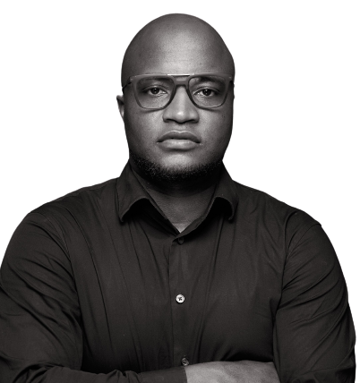

I had a chance to speak with Eden Mathew, a Senior Technical Advisor at D-tree, to learn about his career journey, and to hear his reflections on how technological shifts and the changing global policies on foreign aid are shaping the sector.

### Background

**How did you get to where you are now?**

My background is in Computer Science, which is often referred to with fancier terms like “digital” or “technology” in the digital health field, where I currently work as a Senior Technical Advisor.

I initially started out as a system developer, and my job was to understand a problem and think of ways technology could solve it. I would then design an appropriate system to address the challenge. That was back in 2010 when we were using basic languages such as PHP and JAVA; we didn’t have the fancy frameworks or APIs that we have today.

In 2011, I joined Tanzania Youth Alliance (TAYOA) as an IT coordinator, where I had an opportunity to work on a Social and Behaviour Change (SBC) project. I led the development of a mobile application that sent out messages to youths and key vulnerable populations to educate them about HIV risks, prevention, and transmission. This would mark my initiation into the digital health field, and I became interested in understanding how technology can be used to solve the challenges we see in public health.

Technology has since evolved, and while the tools we developed earlier focused on information sharing, the use cases have expanded, and technology is now used to support service delivery. Take a look at the Unified Community System (UCS) used in the community. It guides a CHW to deliver services based on approved standards and protocols, while also capturing information that can be used for decision making.

Currently, I work at D-tree, where I support the team in applying Human-Centered Design principles with a focus on designing for sustainability. As part of my role, I am also responsible for managing partnerships with the government and partners within the sector to ensure our work is aligned with the government’s priorities and contributes to the wider efforts in public health. We understand that to have a greater impact, we cannot work alone, and we strongly believe in the power of partnerships as a means to achieving that impact.

### Digital Health Landscape

**Do you need to be tech-savvy to work in the digital health sector?**

No, not really. When you look at the digital health sector at its core, it focuses on health systems strengthening, which requires diverse skill sets. To fully realize that, there are three important components: people, processes, and technology.

In any health intervention, there needs to be clearly defined processes in the form of policies and protocols that guide care delivery. Healthcare professionals, such as public health specialists, are best positioned to develop these protocols and guidelines. Similarly, there are many other non-tech roles that are essential in supporting a well functioning healthcare system.

I think there is more emphasis placed on technology because, as a country, we have been lagging behind – particularly in its adoption within the health sector. This is also the case globally; for example, it was only recently that the WHO declared that the future of health is technology. This signals a growing recognition of the role technology plays in improving the quality of and access to healthcare services.

**Where do you see the field in the next 5 to 10 years? i.e., how is it shifting based on ongoing tech trends?**

Reflecting on my personal experience, when I started, technology was primarily used to provide information. Then came a shift towards the digitization of processes, and now, we have platforms that collect data. Looking ahead, we see an increased focus on how this data can be effectively used in decision-making. Some of the questions we will be exploring include: How do we enable systems to act autonomously? How do we make processes and decisions more connected, i.e., IOT? With the rise of agentic AI, we will likely see a shift from using AI to simply provide information to using it to solve problems.

**What are some of the shifts we should expect to see in global health in light of the changing global policies on foreign aid?**

We have already started to experience the effects of the changing policies on foreign aid. For example, in Kenya, there were issues with accessing the EMR, and in Tanzania, the UCS dashboard was not available for two weeks. These shifts have disrupted many existing collaborations, and we have lost many experts due to layoffs. I think we risk losing some of the contributions that have been made, and we may experience a receding progress in the sector. Funding is also becoming increasingly competitive, which means investments will be more limited. This directly affects what organizations can do and may threaten the longevity of the realized impact.

One of the pressing questions now is: How can the government step in to fill the gap? Mobilizing government support requires both technical expertise and strong advocacy, and it is something that takes time. The shift has been abrupt, and we weren’t fully prepared. I think we should anticipate seeing more collaborations among different partners; with limited resources, partnerships will be essential to maximize the impact of our work.

**How should an organization navigate the transformations brought by digital evolution?**

I think organizations need to be aware and stay up to date with ongoing transformations, and one way to do that is by having dedicated roles (like mine) focused on identifying trends and guiding the organization forward. This requires organizations to invest in their employees’ professional development to ensure they are equipped to navigate the changing ecosystem.

Another approach is collaboration with other organizations. Larger organizations often adopt change more slowly, so partnering with smaller entities like startups, which tend to be more adaptive, can help. This way, organizations can leverage each other’s skills and competencies to stay ahead.

**What are some of the strategies you use when engaging with partners?**

When working with partners, we look for alignment in the partnership where everyone can benefit by meeting their objectives and achieving the shared goals. Partnerships require trust, and it is something that is earned over time. They also require nurturing, which takes time and consistency. It is equally important for the parties to be aware of the different roles and respect each other’s contributions in order to foster a healthy, productive relationship. Some of the important questions for organizations to consider include: How do you prioritize the country’s priorities while meeting your organizational objectives? How do you stay committed to the shared vision even when you feel your own organization’s interests are not fully met?

### Looking Ahead

**Where do you see yourself in the next 10 years?**

We are working in a space that is very dynamic; anything can happen at any time, as we have seen over the last few months. That kind of unpredictability is something I’m also taking into account as I plan ahead. I have even started thinking about when it might be the right time for me to step back. You may have seen in the news that, Gates Foundation is also talking about transitioning its activities in the next 20 years. This has prompted me to reflect on how I can continue contributing to advancing our work. I hope to eventually start a local organization that will support the government and continue pushing forward the progress we have made.

**Do you have any words of wisdom for someone just starting out, who is looking to break into the field, especially given the technological shifts and complexities of our current world?**

The complexity has always been there, and I think it is subjective. In 2010 if you asked someone a bit older about the state of technology, they probably would have said things were very complex – with the introduction of mobile phones and social media. But we didn’t appreciate that complexity then, because we were young and had no reference point to base our evaluation on. Having worked in the sector for the past 10 years, I have witnessed many shifts. However, I feel like the next generation will be able to cope well, because they have slightly more of an advantage than we did. Information is now readily available. For example, something that would have required me to read a whole book to figure out might now take just 15 minutes. Learning time has been shortened.

But now the challenge would be how attentive they are, because there are so many distractions. And I think for them, that’s the biggest challenge – how to navigate and stay focused on what’s truly relevant to their career.

### Conclusion

This discussion with Eden Mathew provides an overview of the evolving digital health sector, highlighting its shift from primarily using technology for information sharing to enabling complex service delivery and data-driven decision-making. He emphasizes the importance of partnerships in driving impact while navigating the changing ecosystem. Eden envisions the next leap in digital health as the integration of technologies like agentic AI and IoT.

**Author**: Neema Kafwimi